# The Science in Note-Taking or The Note-Taking in Science

As a double major, I noticed that in my mathematics courses there were a large amount of students with the physical coursebook and a notebook, even though we were provided with a free pdf of our coursebook. Whereas in my computer science courses I didn’t see anybody with the physical coursebook or using a pen and notebook for note-taking.

During multiple lectures myself and two others observed students and recorded their note-taking habits over the lecture period. With this data I was hoping to find patterns amongst the different science based courses and find out if the faculty was an influential factor to differing note-taking methods across the courses.

## More Methods, More Madness?

Firstly, we’ll take a look at how many methods students in each course are using to take notes.

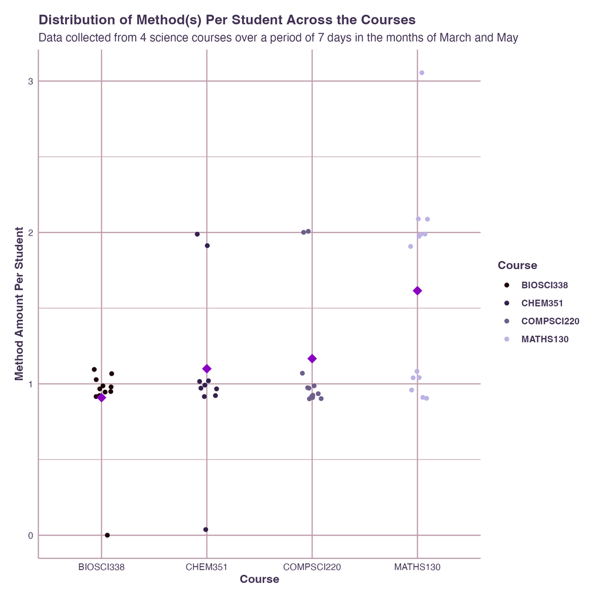

plot3

This suggests that students in MATHS130 are more likely to use multiple note-taking methods during lectures, whereas students in the other three courses tend to rely on a single method throughout the lecture.

## Pick Your Fighter…

What are the different methods these students are using across the courses?

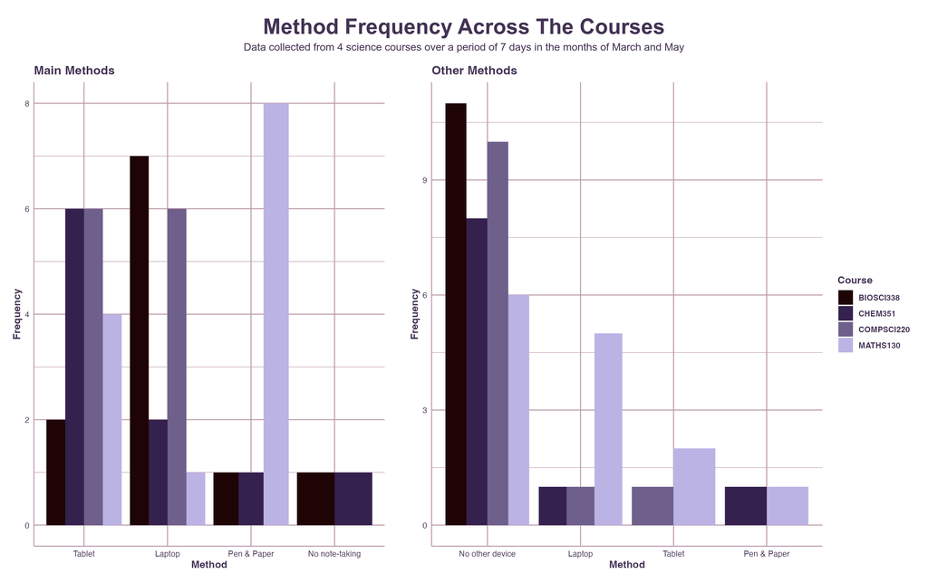

plot2

While note-taking methods vary across courses, certain dominant preferences can be observed within each. Laptops are the primary method used in BIOSCI338, pen and paper dominate in MATHS130, tablets are most commonly used in CHEM351, and COMPSCI220 shows a balanced use of both laptops and tablets.

## PDF or PEN?

We will now look at which courses had students who were more reliant on technology for note-taking, and whether there are still courses where a greater number of students use pen and paper as their primary method

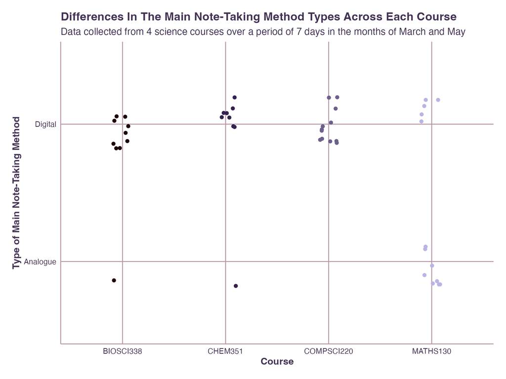

plot1

## In conclusion…

[figure not shown]